# Doc2Vec with classic ML classifier - reduced preprocessing

Gensim Doc2Vec model can be also used to prepare data for classification with either classic ML classifier or neural network. In such a configuration Doc2Vec performs encoding focused on the similarity of documents while classifier performs final classification. One of possible configuration for optimizing such a configuration is to optimize using the final classification performance as the criteria.

The most crucial design considerations related to such a dual model are:

> - the classifier selected to work with Doc2Vec encoded vectors - it should be fast, and with as least configuration required as possible (to reduce model the complexity)
> - the parameters of Doc2Vec model, among others important params are:
>   - encoding vector dimension
>   - encoding algorithm

In the following solution Logistic Regression was used as the final classifier

## Modules and data preprocessing

- some functions related to preprocessing were moved to external module to keep the notebook clean
- some functions used were not included as class method, just to avoid the effort rtequired to make a class suitable for paralell processing

```python
import warnings
from Preprocessor import Preprocessor
from Preprocessor import save_obj as save_obj
from Preprocessor import load_obj as load_obj
import datetime as dt
import sys
import gensim
import pandas as pd
import sklearn
from gensim.models import Doc2Vec
from sklearn.metrics import accuracy_score
from sklearn.linear_model import LogisticRegression
import numpy as np
import gensim
from gensim.models.callbacks import CallbackAny2Vec
from itertools import product
from sklearn.metrics import classification_report
from sklearn.model_selection import GridSearchCV

import matplotlib as mpl
import matplotlib.pyplot as plt
import seaborn as sns

warnings.simplefilter(action='ignore', category=FutureWarning)
warnings.simplefilter(action='ignore', category=DeprecationWarning)
warnings.simplefilter(action='ignore', category=UserWarning)

versions={'NumPy':np.__version__, 'Pandas':pd.__version__, 'Scikit-learn':sklearn.__version__,
          'Matplotlib': mpl.__version__,'Seaborn':sns.__version__,'Gensim':gensim.__version__ }
pd.DataFrame.from_dict(versions,orient='index',columns=['Version']).T
```

|  | NumPy | Pandas | Scikit-learn | Matplotlib | Seaborn | Gensim |
| --- | --- | --- | --- | --- | --- | --- |
| Version | 1.16.4 | 0.25.0 | 0.21.2 | 3.1.1 | 0.9.0 | 3.4.0 |

```python
basedir="src_data//"
preproc=Preprocessor()
preproc.load_raw_texts_from_dir(basedir)
preproc.perform_text_cleanup()
preproc.build_datasets()
preproc.build_train_corpus()
```

```
Datasets loaded
Dataset: train:pos, number of texts: 12500
Dataset: train:neg, number of texts: 12500
Dataset: test:pos, number of texts: 12500
Dataset: test:neg, number of texts: 12500
Texts cleanup finished in 0:00:28.587011
Storing reviews in two dataframes with shapes: train_data: (25000, 2), test_data: (25000, 2)
```

## Doc2Vec + LogisticRegression - finding optimal params for Doc2Vec

The solution is based on Doc2Vec training with LogisticRegression classification after each epoch.

- This approach was selected due to the fact that there is no heuristic which allows to predict the params of Doc2Vec, even a basic one like the vector size
- In addition, Doc2Vec has no function that allows to break training in progress, so the model must be always performed for the fixed number of epochs.

So, to quickly find the reasonable set of hyperparameters three building blocks are necessary:

- master loop for various paramsets for Doc2Vec
- method which encapsulates classifier
- callback class to be invoked after each epoch of Doc2Vec training

### Supporting methods

**classification wrapper method**

```python
def perform_classification(d2v_model, train_data, test_data, eval_fraction=0.2):
    """
    Logistic regression encapsulating method.
    Responsible for mapping data from Doc2Vec vectors and performing the classification.
    The imlementation below can be used to train and test of the classifier
    with train data and test data or
    with train data divided into train and evaluation fraction.
    :param d2v_model: trained Doc2Vec model
    :param train_data: oryginal train data (only target values are used)
    :param test_data: oryginal test data (only target values are used)
    :param eval_fraction: what part of train data is used for evaluation
    :return: accuracy score,
             evaluation type :
                'eval' if subset of train records was used for evaluation
                'test' - if test set was used for evaluation
    """
    eval_size=int(train_data.shape[0]*eval_fraction)
    train_size=train_data.shape[0]-eval_size
    test_size=train_data.shape[0]
    vector_size=d2v_model.vector_size

    if eval_size>0:
        eval_arrays=np.ones((eval_size, vector_size))
        eval_labels=np.ones(eval_size, dtype='int')
        for i in range(eval_size):
            eval_arrays[i] = d2v_model.docvecs[i]
            eval_labels[i] = train_data['Sentiment'].iloc[i]

    train_arrays = np.ones((train_size, vector_size), dtype='float')
    train_labels = np.ones(train_size, dtype='int')
    for i in range(0, train_size):
        train_arrays[i] = d2v_model.docvecs[eval_size+i]
        train_labels[i] = train_data['Sentiment'].iloc[eval_size+i]

    test_arrays = np.ones((test_size, vector_size), dtype='float')
    test_labels = np.ones(test_size, dtype='int')
    for i in range(test_size):
        test_arrays[i] = d2v_model.docvecs[i]
        test_labels[i] = test_data['Sentiment'].iloc[i]


    if eval_fraction>0:
        # use train_data for training and eval data fro evaluation
        clf = LogisticRegression(C=0.75,max_iter=500, solver='lbfgs',n_jobs=12)
        clf.fit(train_arrays, train_labels)
        y_pred = clf.predict(eval_arrays)
        score=accuracy_score(y_true=eval_labels, y_pred=y_pred)
        score_type='eval'
    else:
        # use train_data for training and test data fro evaluation
        clf = LogisticRegression(C=0.75,max_iter=500, solver='lbfgs',n_jobs=12)
        clf.fit(train_arrays, train_labels)
        y_pred = clf.predict(test_arrays)
        score=accuracy_score(y_true=test_labels, y_pred=y_pred)
        score_type='test'
    return score, score_type
```

**callback class**

```python
class progress_callback(CallbackAny2Vec):
    def __init__(self, model_params, model_name:str, results_dictionary:dict, temp_results:dict, save_path=None, verbose=True):
        """
        Class used as a callback method for Doc2Vec.
        For each iteration onlty data from best epoch is stored and written to a dictionary.
        Dataset from Doc2Vec model is stored as a pickle.
        :param model_params: params used during optimization iteration
        :param model_name: the name of the model (it can be any string, but must be unique)
        :param results_dictionary: the dictionary to store results in
        :param save_path: the dictionary to store results dictionary and data from best model
        :param verbose: wheather to print output message
        """
        self.epoch = 0
        self.no_improvement=0
        self.best_score=0
        self.best_epoch=0
        self.save_path=save_path
        self.verbose=verbose
        self.model_name=model_name
        self.model_params=model_params
        self.results_dictionary=results_dictionary
        self.temp_results=temp_results

    def on_epoch_end(self, model):
        score, score_type=perform_classification(d2v_model=model,train_data=preproc.train_data,test_data=preproc.test_data,eval_fraction=0.2)
        self.temp_results[(self.epoch)]=score
        if score>self.best_score:
            self.no_improvement=0
            self.best_score=score
            self.best_epoch=self.epoch
            vectors_filename=''
            if self.save_path:
                vectors_filename = self.save_path + self.model_name + \
                                   '_best_model.pkl'
                save_obj(model.docvecs, vectors_filename)
            self.results_dictionary[(self.model_name)]={
                **self.model_params,
                **{'Epoch':self.epoch,
                   'Best score':score,
                   'Score type':score_type,
                   'Vectors filename':vectors_filename}}
            if self.verbose:
                print('Epoch: {}, Score: {:.4f}, Best score: {:.4f}, Score type: {}, Best epoch: {}'.format(
                    self.epoch, score, self.best_score, score_type, self.best_epoch))
        else:
            self.no_improvement+=1
            if self.verbose:
                print('No improvement for {} times, Epoch {}, Score: {:.4f}, Best score: {}'.format(self.no_improvement, self.epoch, score, self.best_score))
        self.epoch += 1
```

### Doc2Vec param searching

- only a few iterations will be performed here for ilustrative purpose
- the same method was used with a few instances of separated processes

```
vector_size:50 dm:0 min_count:3 sample:0.0001 dm_mean:0 max_vocab_size:None repetition:1 session id:SESSION_1
Processed 1/2, Score: 0.8832, duration: 0:04:33.733141
```

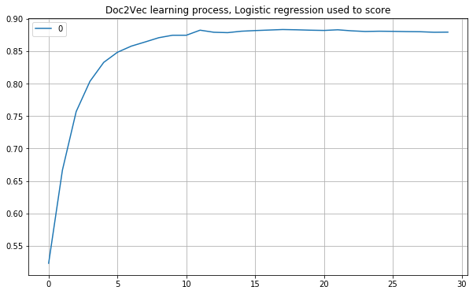

```
vector_size:100 dm:0 min_count:3 sample:0.0001 dm_mean:0 max_vocab_size:None repetition:1 session id:SESSION_1
Processed 2/2, Score: 0.8844, duration: 0:05:00.029047
```

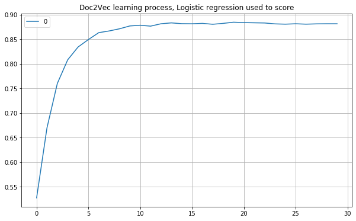

```
0:09:34.100164
```

```python
DOC2VEC_EPOCHS=30
MAX_WORKERS=12 # the best value is number of physical cores (at least for WIndows and Threadripper)
OUTPUT_PATH=None
doc2vec_results={}

start=dt.datetime.now()

d2v_params = {
    'vector_size': [50,100],
    'dm': [0],
    'min_count': [3],
    'sample': [1e-4],
    'dm_mean': [0],
    'max_vocab_size': [None],
    'repetition':[1],
    'session id': ['SESSION_1']
}

def dict_product(d):
    keys = d.keys()
    for element in product(*d.values()):
        yield dict(zip(keys, element))

paramset = list(dict_product(d2v_params))
_, iternum=0, len(paramset)
for params in paramset:
    iter_start=dt.datetime.now()
    temp_results={}
    _+=1
    print(' '.join([':'.join([str(k), str(params[k])]) for k in params]))
    model_name='__'.join(['_'.join([str(k),str(params[k])]) for k in params])
    d2v_model=Doc2Vec(vector_size=params['vector_size'],
                      dm=params['dm'],
                      min_count=params['min_count'],
                      sample=params['sample'],
                      workers=MAX_WORKERS,
                      epochs=DOC2VEC_EPOCHS,
                      dm_mean=params['dm_mean'],
                      max_vocab_size=params['max_vocab_size'],
                      callbacks=[
                        progress_callback(model_params=params,
                                          model_name=model_name,
                                          temp_results=temp_results,
                                          save_path=OUTPUT_PATH,
                                          verbose=False,
                                          results_dictionary=doc2vec_results)

                      ])
    d2v_model.build_vocab(documents=preproc.train_corpus)
    d2v_model.train(preproc.train_corpus,
                    total_examples=d2v_model.corpus_count,
                    epochs=DOC2VEC_EPOCHS)
    if OUTPUT_PATH:
        save_obj(doc2vec_results,"{}DOC2VEC_results_{}.pkl".format(OUTPUT_PATH, params['session_id']))
        pd.DataFrame.from_dict(doc2vec_results).T.to_excel("{}DOC2VEC_results_{}.xlsx".format(OUTPUT_PATH, params['session id']))
    print('Processed {}/{}, Score: {:.4f}, duration: {}'.format(_, iternum, doc2vec_results[model_name]['Best score'], dt.datetime.now()-iter_start))
    fig,ax=plt.subplots(1,1,figsize=(10,6))
    sns.lineplot(data=pd.DataFrame.from_dict(temp_results,orient='index'),ax=ax)
    ax.grid()
    ax.set_title('Doc2Vec learning process, Logistic regression used to score')
    plt.show()
print(dt.datetime.now()-start)
```

## Searching for vectorsize

### Initial wide search

- In order to find the right vector size values from 50 to 500 were examined with interval 50
- For each vector size 12 iterations were performed, 30 epochs each
- in paralell two min_count values were examined: 2 and 3
- the experiment was performed in fur independent sessions, but all of them used the same dataset, without shuufling between iterations

```python
result_df=pd.DataFrame()
for i in range (1,5):
    _=pd.read_excel('doc2vec_results//DOC2VEC_results_{}.xlsx'.format(i))
    result_df=result_df.append(_)
result_df=result_df.reset_index(drop=True)
result_df=result_df[['vector_size','min_count','repetition','session id','Epoch','Best score','Score type']]
result_df.head()
```

|  | vector_size | min_count | repetition | session id | Epoch | Best score | Score type |
| --- | --- | --- | --- | --- | --- | --- | --- |
| 0 | 50 | 3 | 1 | 1 | 21 | 0.8924 | eval |
| 1 | 50 | 3 | 2 | 1 | 22 | 0.8876 | eval |
| 2 | 50 | 3 | 3 | 1 | 29 | 0.8880 | eval |
| 3 | 100 | 3 | 1 | 1 | 22 | 0.8960 | eval |
| 4 | 100 | 3 | 2 | 1 | 18 | 0.8888 | eval |

[figure not shown]

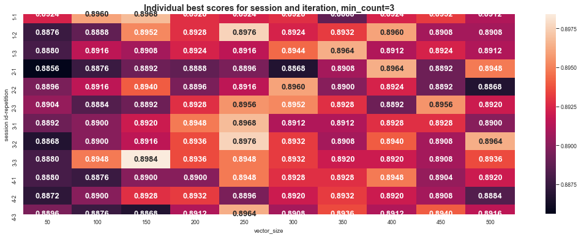

```python
sns.set_style("whitegrid")
sns.set_context("paper")
title_fonts={'fontsize':14, 'weight':'bold'}
fig,ax = plt.subplots(nrows=1, ncols=2, figsize=(16,6), sharey=True)
sns.boxplot(data=result_df.loc[result_df['min_count']==3,:],x='vector_size',y='Best score',ax=ax[0],palette='OrRd',width=0.75)
ax[0].set_title('Best scores by vector size, with min_count=2',fontdict=title_fonts)
# sns.boxplot(data=result_df.loc[result_df['min_count']==3,:],x='vector_size',y='Best score',ax=ax[1],palette='OrRd',width=0.75);
# ax[1].set_title('Best scores by vector size, with min_count=3', fontdict=title_fonts)

fig,ax=plt.subplots(nrows=1, ncols=1, figsize=(18,6))
sns.heatmap(pd.pivot_table(data=result_df.loc[result_df['min_count']==3,:],values='Best score',index=['session id','repetition'],columns='vector_size'),
            ax=ax, annot=True, fmt=".4f",annot_kws={'fontsize':13,'weight':'bold'});
ax.set_title('Individual best scores for session and iteration, min_count=3',fontdict=title_fonts);
```

### Narrowed search

```python
result_df=pd.DataFrame()
for i in range (1,5):
    _=pd.read_excel('doc2vec_results//DOC2VEC_results_{}.xlsx'.format(i))
    result_df=result_df.append(_)
result_df=result_df.reset_index(drop=True)
# result_df=result_df[['vector_size','min_count','repetition','session id','Epoch','Best score','Score type']]
result_df.head()
```

|  | Unnamed: 0 | vector_size | dm | min_count | sample | dm_mean | max_vocab_size | repetition | session id | Epoch | Best score | Score type | Vectors filename |
| --- | --- | --- | --- | --- | --- | --- | --- | --- | --- | --- | --- | --- | --- |
| 0 | vector_size_240__dm_0__min_count_3__sample_0.0... | 240 | 0 | 3 | 0.0001 | 0 | NaN | 1 | 1 | 16 | 0.8884 | eval | S:\Python\CaseStudies\NLP\Doc2Vec\Combined mod... |
| 1 | vector_size_240__dm_0__min_count_3__sample_0.0... | 240 | 0 | 3 | 0.0001 | 0 | NaN | 2 | 1 | 18 | 0.8884 | eval | S:\Python\CaseStudies\NLP\Doc2Vec\Combined mod... |
| 2 | vector_size_240__dm_0__min_count_3__sample_0.0... | 240 | 0 | 3 | 0.0001 | 0 | NaN | 3 | 1 | 12 | 0.8900 | eval | S:\Python\CaseStudies\NLP\Doc2Vec\Combined mod... |
| 3 | vector_size_250__dm_0__min_count_3__sample_0.0... | 250 | 0 | 3 | 0.0001 | 0 | NaN | 1 | 1 | 17 | 0.8920 | eval | S:\Python\CaseStudies\NLP\Doc2Vec\Combined mod... |
| 4 | vector_size_250__dm_0__min_count_3__sample_0.0... | 250 | 0 | 3 | 0.0001 | 0 | NaN | 2 | 1 | 12 | 0.8892 | eval | S:\Python\CaseStudies\NLP\Doc2Vec\Combined mod... |

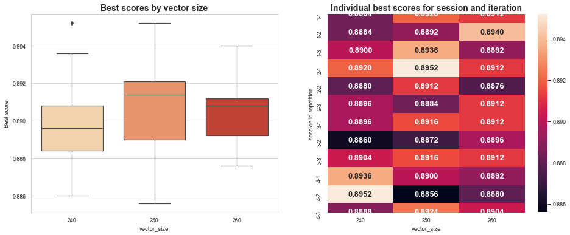

```python
sns.set_style("whitegrid")
sns.set_context("paper")
title_fonts={'fontsize':14, 'weight':'bold'}

fig,ax = plt.subplots(nrows=1, ncols=2, figsize=(16,6))
sns.boxplot(data=result_df, x='vector_size',y='Best score',ax=ax[0],palette='OrRd',width=0.75)
ax[0].set_title('Best scores by vector size',fontdict=title_fonts)

sns.heatmap(pd.pivot_table(data=result_df, values='Best score',index=['session id','repetition'],columns='vector_size'),
            ax=ax[1], annot=True, fmt=".4f",annot_kws={'fontsize':13,'weight':'bold'});
ax[1].set_title('Individual best scores for session and iteration',fontdict=title_fonts);
```

```python
pd.pivot_table(data=result_df, values='Best score',index='vector_size', aggfunc=['mean','std']).T
```

|  | vector_size | 240 | 250 | 260 |
| --- | --- | --- | --- | --- |
| mean | Best score | 0.890000 | 0.890667 | 0.890333 |
| std | Best score | 0.002541 | 0.002720 | 0.001738 |

### Doc2Vec and logistic regression scoring

```python
result_df.loc[result_df['vector_size']==250].sort_values(by='Best score', ascending=False).iloc[0]['Vectors filename']
```

```
'S:\\Python\\CaseStudies\\NLP\\Doc2Vec\\Combined model\\doc2vec_results\\vector_size_250__dm_0__min_count_3__sample_0.0001__dm_mean_0__max_vocab_size_None__repetition_1__session id_2_best_model.pkl'
```

```python
dirname="R://"
vector_data=load_obj(result_df.loc[result_df['vector_size']==250].sort_values(by='Best score', ascending=False).iloc[0]['Vectors filename'])
train_data=pd.read_pickle(dirname+'train_data.pkl')
test_data=pd.read_pickle(dirname + 'test_data.pkl')
```

**evaluation score**

```python
eval_fraction=0.1
eval_size=int(train_data.shape[0]*eval_fraction)
train_size=train_data.shape[0]-eval_size
test_size=test_data.shape[0]
vector_size=250

eval_arrays=np.ones((eval_size, vector_size))
eval_labels=np.ones(eval_size, dtype='int')
for i in range(eval_size):
    eval_arrays[i] = vector_data[i]
    eval_labels[i] = train_data['Sentiment'].iloc[i]

train_arrays = np.ones((train_size, vector_size), dtype='float')
train_labels = np.ones(train_size, dtype='int')
for i in range(0, train_size):
    train_arrays[i] = vector_data[eval_size+i]
    train_labels[i] = train_data['Sentiment'].iloc[eval_size+i]

clf = LogisticRegression(C=0.75,max_iter=500, solver='lbfgs',n_jobs=12)
clf.fit(train_arrays, train_labels)
y_pred = clf.predict(eval_arrays)
print(classification_report(y_true=eval_labels, y_pred=y_pred,digits=4))
```

```
              precision    recall  f1-score   support

           0     0.8851    0.9012    0.8931      1214
           1     0.9051    0.8896    0.8973      1286

    accuracy                         0.8952      2500
   macro avg     0.8951    0.8954    0.8952      2500
weighted avg     0.8954    0.8952    0.8952      2500
```

```python
# saving datasets for use in stage 2
path_to_save='datasets_stage_1//train_eval_test//'
save_obj(train_arrays,path_to_save+'train_arrays')
save_obj(eval_arrays,path_to_save+'eval_arrays')
save_obj(test_arrays,path_to_save+'test_arrays')
save_obj(train_labels,path_to_save+'train_labels')
save_obj(eval_labels,path_to_save+'eval_labels')
save_obj(test_labels,path_to_save+'test_labels')
```

**Test score**

```python
train_size=train_data.shape[0]
test_size=test_data.shape[0]
vector_size=250

train_arrays = np.ones((train_size, vector_size), dtype='float')
train_labels = np.ones(train_size, dtype='int')
for i in range(0, train_size):
    train_arrays[i] = vector_data[i]
    train_labels[i] = train_data['Sentiment'].iloc[i]

test_arrays = np.ones((test_size, vector_size), dtype='float')
test_labels = np.ones(test_size, dtype='int')
for i in range(test_size):
    test_arrays[i] = vector_data[train_size+i]
    test_labels[i] = test_data['Sentiment'].iloc[i]

clf = LogisticRegression(C=0.75,max_iter=500, solver='lbfgs',n_jobs=12)
clf.fit(train_arrays, train_labels)
y_pred = clf.predict(test_arrays)
print(classification_report(y_true=test_labels, y_pred=y_pred,digits=4))
```

```
              precision    recall  f1-score   support

           0     0.8851    0.8941    0.8896     12500
           1     0.8930    0.8839    0.8884     12500

    accuracy                         0.8890     25000
   macro avg     0.8890    0.8890    0.8890     25000
weighted avg     0.8890    0.8890    0.8890     25000
```

The obtained result 0.8890 is slightly worse than for evaluation data (0.1 of training fraction, but still quite good).  
Let's check how much we can improve it using with parameter tuning for LogisticRegression

```python
grid_params={
    'penalty': ['l1','l2','elasticnet', 'none'],
    'C':[.01, .05, .1, .25, .5, .75],
    'fit_intercept': [True,False],
    'l1_ratio':[.1, .25, .5, .75, .9]
}

grid=GridSearchCV(estimator= LogisticRegression(max_iter=1000, solver='saga'),
                  param_grid=grid_params,
                  scoring='accuracy', n_jobs=12, refit=True, cv=5, verbose=1)
grid.fit(train_arrays,train_labels)
print(grid.best_params_)
```

```
Fitting 5 folds for each of 240 candidates, totalling 1200 fits
```

```
[Parallel(n_jobs=12)]: Using backend LokyBackend with 12 concurrent workers.
[Parallel(n_jobs=12)]: Done  26 tasks      | elapsed:    4.4s
[Parallel(n_jobs=12)]: Done 176 tasks      | elapsed:   22.3s
[Parallel(n_jobs=12)]: Done 426 tasks      | elapsed:   54.5s
[Parallel(n_jobs=12)]: Done 776 tasks      | elapsed:  1.7min
[Parallel(n_jobs=12)]: Done 1200 out of 1200 | elapsed:  2.8min finished
```

```
{'C': 0.05, 'fit_intercept': True, 'l1_ratio': 0.25, 'penalty': 'elasticnet'}
```

```python
y_pred = grid.predict(test_arrays)
print(classification_report(y_true=test_labels, y_pred=y_pred,digits=4))
```

```
              precision    recall  f1-score   support

           0     0.8858    0.8970    0.8913     12500
           1     0.8956    0.8843    0.8899     12500

    accuracy                         0.8906     25000
   macro avg     0.8907    0.8906    0.8906     25000
weighted avg     0.8907    0.8906    0.8906     25000
```